# hw6

Die Hu

4/15/2021

```r
#install.packages("rstanarm")
library(rstanarm)
```

```r
library(broom)
library(ggplot2)
library(viridis)
data(roaches)
summary(roaches)
```

```
##        y              roach1         treatment          senior
##  Min.   :  0.00   Min.   :  0.00   Min.   :0.0000   Min.   :0.0000
##  1st Qu.:  0.00   1st Qu.:  1.00   1st Qu.:0.0000   1st Qu.:0.0000
##  Median :  3.00   Median :  7.00   Median :1.0000   Median :0.0000
##  Mean   : 25.65   Mean   : 42.19   Mean   :0.6031   Mean   :0.3053
##  3rd Qu.: 24.00   3rd Qu.: 50.50   3rd Qu.:1.0000   3rd Qu.:1.0000
##  Max.   :357.00   Max.   :450.00   Max.   :1.0000   Max.   :1.0000
##    exposure2
##  Min.   :0.200
##  1st Qu.:1.000
##  Median :1.000
##  Mean   :1.021
##  3rd Qu.:1.000
##  Max.   :4.286
```

```r
roaches
```

```
##       y roach1 treatment senior exposure2
## 1   153 308.00         1      0 0.8000000
## 2   127 331.25         1      0 0.6000000
## 3     7   1.67         1      0 1.0000000
## 4     7   3.00         1      0 1.0000000
## 5     0   2.00         1      0 1.1428571
## 6     0   0.00         1      0 1.0000000
## 7    73  70.00         1      0 0.8000000
## 8    24  64.56         1      0 1.1428571
## 9     2   1.00         0      0 1.0000000
## 10    2  14.00         0      0 1.1428571
## 11    0 138.25         0      0 1.0000000
## 12   21  16.00         0      0 1.0000000
## 13    0  97.00         0      0 1.0000000
## 14  179  98.00         0      0 0.8000000
```

[output cut: 248 more lines]

### Question 1

Fit a Poisson regression where the number of roaches trapped is a function of roach1,treatment, and senior. Make sure to include an offset for the exposure2 variable.

```r
# Estimate original model
glm <- glm(y ~ roach1 + treatment + senior, offset = log(exposure2),data = roaches, family = poisson)
#summary(glm)
# install.packages("arm")
library(arm)
display(glm)
```

```
## glm(formula = y ~ roach1 + treatment + senior, family = poisson,
##     data = roaches, offset = log(exposure2))
##             coef.est coef.se
## (Intercept)  3.09     0.02
## roach1       0.01     0.00
## treatment   -0.52     0.02
## senior      -0.38     0.03
## ---
##   n = 262, k = 4
##   residual deviance = 11429.5, null deviance = 16953.7 (difference = 5524.2)
```

### Question 2

Using expand.grid to make a grid of predictor variables at which to get fited values and augment to get the fitted values at the grid of predictors, make a plot that shows the model you just fit. What does your plot show you about the effect of treatment? Of the effect of a seniors-only building?

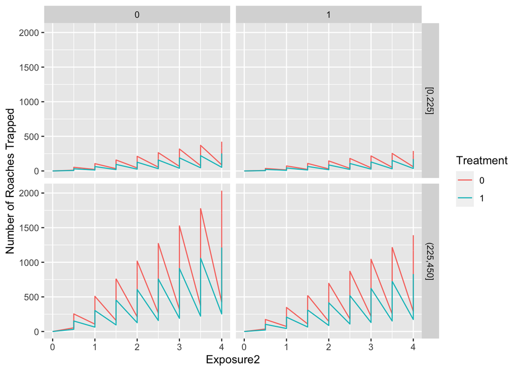

```r
roaches.grid = expand.grid(exposure2 = seq(0,4,0.5), roach1 = 0:450, treatment = c(0, 1), senior = c(0,1))
roaches.grid_glm = augment(glm, type.predict = 'response', type.residuals = 'pearson', newdata = roaches.grid)

ggplot(roaches.grid_glm, aes(x = exposure2, y = .fitted, group = factor(treatment), color = factor(treatment))) +
  geom_line()+
  facet_grid(cut_number(roach1, n=2) ~ senior) +
  xlab("Exposure2") +
  ylab("Number of Roaches Trapped") +
  labs(color = "Treatment")
```

According to the graph above, it shows that the result is significantly higher for the treatment of value 0 compare to treatment of value 1. Also, the senior of value 0 has larger range of result than the senior of value 1.

### Question 3

Make a residuals-vs.-fitted values plot (it might be easier to visualize if you plot the logfitted values instead of the raw fitted values). Does the residual plot suggest that overdispersion is a problem? What would you do to solve this issue (no need to run a new model)?

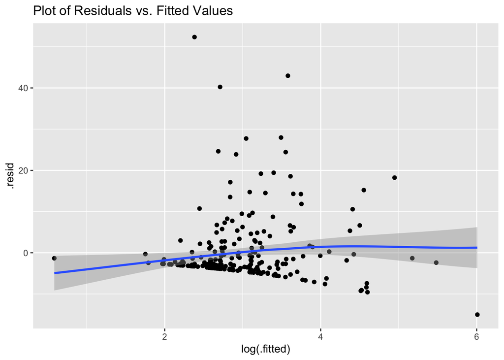

```r
temp = augment(glm, type.predict = "response", type.residuals = "pearson")
ggplot(temp, aes(x = log(.fitted), y = .resid)) +
  geom_point() +
  geom_smooth(method = "loess", span = 1, method.args = list(degree = 1)) +
  ggtitle("Plot of Residuals vs. Fitted Values")
```

```r
overdispersion = sum(temp$.resid^2) / df.residual(glm)
overdispersion
```

```
## [1] 65.43815
```

According to the above graph and the result of calculated dispersion, we can say that in our case, the dispersion is an issue needed for attention since it is 65.43815 which is way larger than 1.

A solution I would suggest for the dispersion is using Quasipoisson mode.